# Formula E Championship Predictions

Fighting Wolves: Jiayi Wan, Wanfang Zhen, George Zhu, Yifu Li & Yunrui Lyu

2023-11-30

## Introduction

Formula E championship, known for its unpredictability due to a myriad of factors such as driver expertise, car performance, circuit characteristics, and race formats, ignites interest in statistical exploration. Emphasizing an unbiased approach, this report aims to explore the relationship between the number of races drivers participated in and their performance.

The report commences with a concise delineation of the methodology for curating pristine data, coupled with an explanation of the selected models. Subsequently, tables, figures, and summary values are presented in a clear and explanatory manner, followed by four linear regression models developed to explore various facets of the data, with each model addressing different conditions such as season exclusions and minimum participation requirements. This study subsequently analyses the model’s fitting, advantages, and limitations, and proposes feasible recommendations for future in-depth research. Finally, the report addresses the research objectives and questions, offering responses based on the statistical analysis.

## Methodology

The research process harnessed the capabilities of the tidyverse, tidymodels, and ggplot2 packages, integral tools in the realm of data analysis.

During the initial stage of data cleansing, functions such as group_by(), select(), slice(), filter(), and summarize () played a pivotal role. These functions meticulously shaped and refined the raw data into a structured and coherent format. Moreover, they also helped merge information needed such as average points. These data frames, encompassing driver details, total points, average points, and frequency derived from FERR0, laid the groundwork for subsequent analytical endeavors.

Once the requisite data was meticulously gathered, a linear regression analysis was employed to discern potential correlations between various variables. This critical step was executed using ggplot(), with aes(x = Freq, y = avg_points) effectively mapping the relationship. The function geom_point() crafted a point diagram, while geom_smooth(method = “lm”, se = FALSE) elegantly overlaid the linear regression line, simultaneously eliminating any surrounding shadows. The visualizations thus produced offered insightful glimpses, potentially guiding preliminary predictive analyses.

Based on the insights obtained from the previous stage, a more detailed investigation of the relationship between average total points and frequency (of attending races) was carried out. Average total point referred to the average points each driver earned throughout races they attended, which largely reflected the racing level of these drivers. Frequency, on the other hand, indicated the number of competitions the drivers had participated in, which was correlated to the experience of these drivers.

An initial model (model1) was plotted using linear_reg(), which set the engine as “lm”. Then the command fit() was piped, providing the name of the data and relationship avg_points ~ Freq. Examining the outcomes of this model revealed crucial insights into the estimated intercept and the correlation between these variable pairs.

The original model was visualized by ggplot(). The function geom_point() told R which type of diagram should be plotted. geom_smooth() provided visualization of the linear regression line as well. To augment the clarity and aesthetic appeal of these diagrams, the labs() layer was incorporated, ensuring the lucid presentation of information.

Three additional models, named model2, model3, and model4, evolved from the foundational model. They applied specific filters: “season != 7”, “Freq >= 3”, and a combination of both, supported by derived data frames. These data frames, created using a blend of filter(), group_by(), and summarize(), extracted essential information tailored to meet diverse conditions. The efficacy of all four models was appraised using the r squared value obtained from the glance()$r.squared function. The proximity of the r-squared value to 1 was indicative of the strength of the correlation between the x-y variables.

The visualization stage of the derived model was similar to the previous procedure. ggplot() completed the work. Point diagrams were plotted by geom_point(). geom_smooth(method = “lm”, se = FALSE) was there to visualize the linear regression line. labs() layer was added as well to improve the presentation of the diagrams.

## Data

1 Graphs

According to The Official Home of Formula E, the champion of the Formula E championship is determined by the driver with the highest cumulative points in the season. The accompanying chart lists the drivers with the highest total points across seven seasons, and this data is compared with the champion information provided by Formula E Chronicles(2022). Additionally, this analysis includes a test to determine whether these champions participated in every race of their respective seasons.

```
## # A tibble: 7 × 4
##   season driver                 total_points attended_all_races
##    <dbl> <chr>                         <dbl> <lgl>
## 1      1 Nelson Piquet Jr.               144 TRUE
## 2      2 Sébastien Buemi                 155 TRUE
## 3      3 Lucas di Grassi                 181 TRUE
## 4      4 Jean-Éric Vergne                198 TRUE
## 5      5 Jean-Éric Vergne                136 TRUE
## 6      6 António Félix da Costa          158 TRUE
## 7      7 Nyck de Vries                    32 TRUE
```

(Graph 1.1)

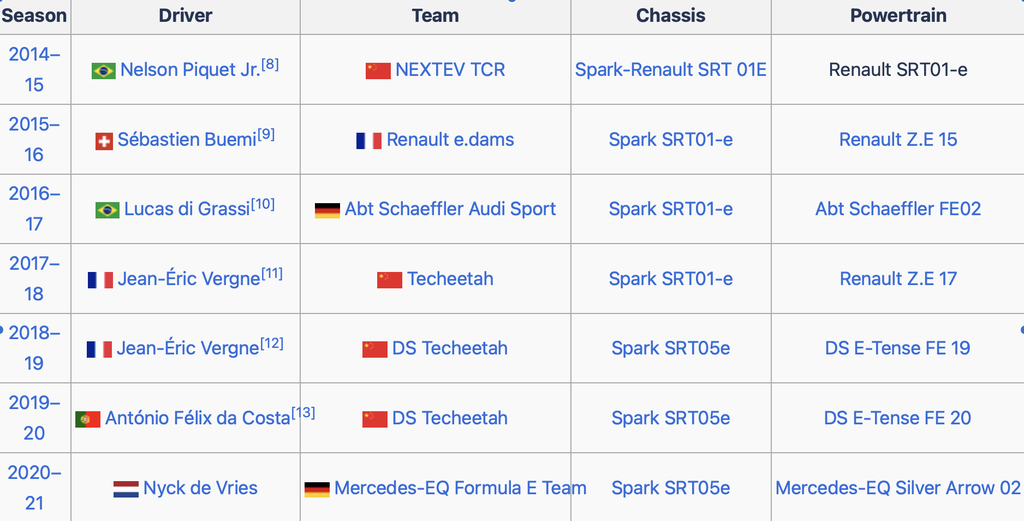

(Graph 1.2)

2 Example

The table below is a subset data from the most representative Season 1, with new variables such as frequency (number of race participation), total_points (cumulative points), and avg_points (average points) being added.

```
## # A tibble: 16 × 4
##    driver                 total_points average_points frequency
##    <chr>                         <dbl>          <dbl>     <int>
##  1 Sam Bird                        103           9.36        11
##  2 Nico Prost                       89           8.09        11
##  3 Jean-Éric Vergne                 70           7.78         9
##  4 António Félix da Costa           51           6.38         8
##  5 Loïc Duval                       42           6            7
##  6 Bruno Senna                      40           3.64        11
##  7 Daniel Abt                       32           2.91        11
##  8 Nick Heidfeld                    31           2.82        11
##  9 Jaime Alguersuari                30           3.33         9
## 10 Stéphane Sarrazin                22           2           11
## 11 Franck Montagny                  18           9            2
## 12 Karun Chandhok                   18           1.64        11
## 13 Scott Speed                      18           4.5          4
## 14 Charles Pic                      16           3.2          5
## 15 Oriol Servià                     16           4            4
## 16 Jarno Trulli                     15           1.36        11
```

(Table 2.1)

3 Models

Model 1 is based on the original data set FERR and specifically establishes the positive correlation between the participation frequency and the average scores of all drivers over the past seven seasons.

```
## parsnip model object
##
##
## Call:
## stats::lm(formula = avg_points ~ Freq, data = data)
##
## Coefficients:
## (Intercept)         Freq
##     0.99089      0.09482
```

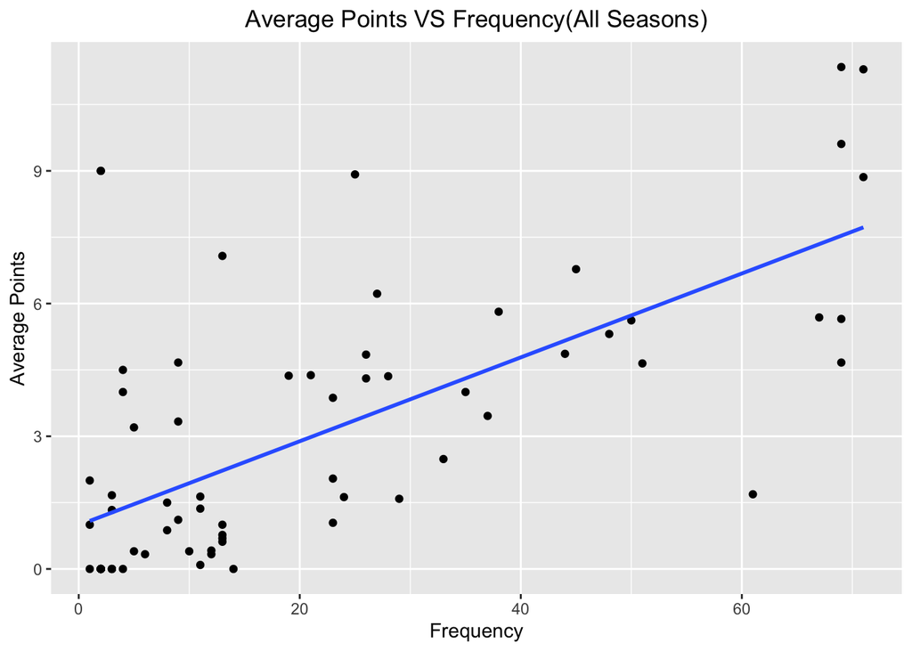

```
## [1] 0.4449197
```

(Model 3.1)

Model 2 excludes all data from the 7th season and focuses solely on the relationship between frequency and average points in the first six seasons. The reason for this is that the 7th season had a maximum of only two races, potentially making the data from that season unrepresentative. Formula E Wiki also notes that the 2019/20 season experienced a mid-season hiatus from March to July 2020 due to the pandemic.

```
## parsnip model object
##
##
## Call:
## stats::lm(formula = avg_points ~ Freq, data = data)
##
## Coefficients:
## (Intercept)         Freq
##     1.02456      0.09609
```

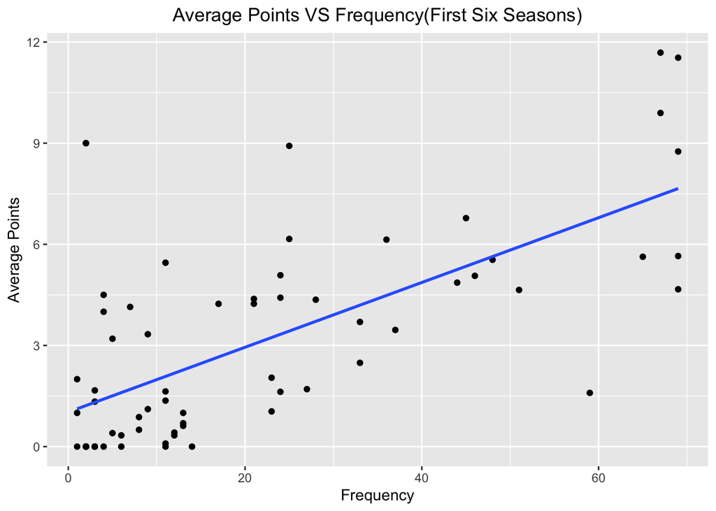

```
## [1] 0.4344037
```

(Model 3.2)

```
## parsnip model object
##
##
## Call:
## stats::lm(formula = avg_points ~ Freq, data = data)
##
## Coefficients:
## (Intercept)         Freq
##     0.84736      0.09798
```

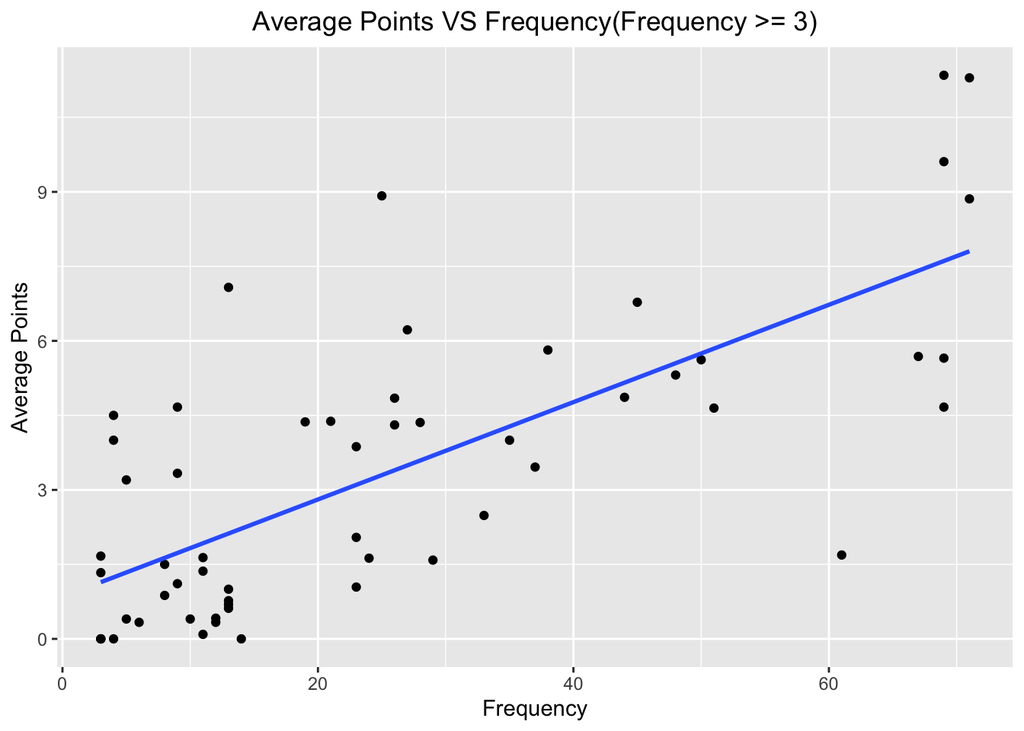

```
## [1] 0.5218821
```

(Model 3.3)

Model 4 is generated by combining the conditions of Model 2 and Model 3 since these two factors may affect the final outcomes of the model.

```
## parsnip model object
##
##
## Call:
## stats::lm(formula = avg_points ~ Freq, data = data)
##
## Coefficients:
## (Intercept)         Freq
##      0.7598       0.1020
```

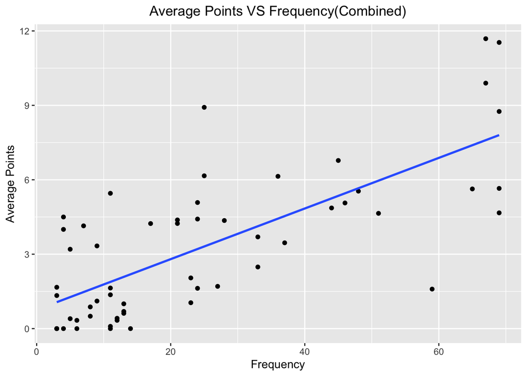

```
## [1] 0.5311562
```

(Model 3.4)

## Evaluation

The analysis is augmented by Graph 1.1, which visualizes the highest-scoring drivers per season, juxtaposed with championship data(Graph 1.2) from 2014 to 2021. A key observation here is the consistent championship attainment by the highest accumulated points, suggesting a strong link between scoring and overall success. Another notable finding is that all championship drivers participated in all races of the season, suggesting a certain relationship between ‘points’ and “frequency”.

To test this hypothesis, Models 1 through 4 were constructed. Model 1 indeed demonstrated a positive correlation between the two variables, but due to significant data dispersion, it resulted in a relatively low R-squared value of 0.445. Considering the reduction of outliers and the exclusion of data from the 7th season, the results were unexpected as Model 2’s R-squared value decreased to 0.434. This indicated that while some outliers were removed, more valid data points were inadvertently excluded. To address this issue, data was optimized by filtering the frequency threshold within a reasonable range (frequency >= 3), resulting in an improved R-squared value of 0.522. Finally, to validate whether both filtering conditions would have a simultaneous effect, Model 4 combined these two filtering criteria and achieved the highest R-squared value of 0.531.

However, four primary research limitations have been identified. First, the filtering criteria may introduce bias, thus distorting the representation of the data. Second, the filtering process could lead to a significant reduction in the number of samples, potentially failing to capture statistically general phenomena. In addition, some unavoidable random errors, including technical failures, weather conditions, and track conditions, may affect the accuracy of the predictions. MLANDRY (2021) also mentioned that the top six drivers were forced into the first group, which had dirtier tracks and less grip. Finally, R-squared values less than 1 still indicate that factors beyond the current scope, such as team dynamics, driver skill progression, and external circumstances, play a significant role in the outcomes.

To enhance the comprehensiveness of the study, future research should incorporate additional variables that could influence a driver’s performance. These may include team strategies, technological advancements in vehicles, and even psychological factors affecting drivers during races. An expanded data set, possibly encompassing more racing seasons, would also provide a broader base for analysis, potentially leading to more conclusive insights.

## Conclusion

In conclusion, this report demonstrates a moderate positive correlation between race participation and driver performance in Formula E. Utilizing data tidying, summarizing, visualizing, and linear regression analysis, it improved the model’s R-squared value from 0.44 to 0.53 by removing detected outliers. Despite potential biases and reduced sample sizes, the findings of this study are expected to bring some possible inspirations to the field of race, for instance, team managers who aim to optimize their drivers’ performance.

## References

Formula E Chronicles 2022, Formula E Champions, Formula E Chronicles, viewed 30 Nov 2023, https://formulaechronicles.com/list-of-formula-e-champions/#:~:text=Points%20are%20awarded%20based%20on,the%20respective%20championship%20or%20trophy.

Formula E Wiki, S n.d., 2019/20 Formula E Championship, Formula E Wiki, viewed 30 Nov 2023, https://formulae.fandom.com/wiki/2019/20_Formula_E_Championship.

MLANDRY 2021, Formula E Championship, Kaggle, viewed 30 Nov 2023, https://www.kaggle.com/datasets/mlandry/formula-e-championship.

The Official Home of Formula E, S n.d., Rules and Regulations, The Official Home of Formula E, viewed 30 Nov 2023, https://www.fiaformulae.com/en/championship/rules-and-regulations#:~:text=Championship%20and%20standings,most%20points%20over%20the%20season..